# Risk Factor Analysis

## Outcome Variable

**Outcome Variable:** ever_wasted

## Predictor Variables

**Intervention Variable:** mhtcm

**Adjustment Set:**

- arm
- W_mage
- meducyrs
- feducyrs
- delta_W_mage
- delta_meducyrs
- delta_feducyrs

## Stratifying Variables

The analysis was stratified on these variable(s):

- agecat
- studyid
- country

## Data Summary

| agecat | studyid | country | mhtcm | ever_wasted | n_cell | n |
| --- | --- | --- | --- | --- | --- | --- |
| 0-24 months | COHORTS | GUATEMALA | >=155 cm | 0 | 121 | 1275 |
| 0-24 months | COHORTS | GUATEMALA | >=155 cm | 1 | 44 | 1275 |
| 0-24 months | COHORTS | GUATEMALA | <151 cm | 0 | 605 | 1275 |
| 0-24 months | COHORTS | GUATEMALA | <151 cm | 1 | 230 | 1275 |
| 0-24 months | COHORTS | GUATEMALA | [151-155) cm | 0 | 214 | 1275 |
| 0-24 months | COHORTS | GUATEMALA | [151-155) cm | 1 | 61 | 1275 |
| 0-24 months | COHORTS | INDIA | >=155 cm | 0 | 381 | 1905 |
| 0-24 months | COHORTS | INDIA | >=155 cm | 1 | 190 | 1905 |
| 0-24 months | COHORTS | INDIA | <151 cm | 0 | 547 | 1905 |
| 0-24 months | COHORTS | INDIA | <151 cm | 1 | 276 | 1905 |
| 0-24 months | COHORTS | INDIA | [151-155) cm | 0 | 341 | 1905 |
| 0-24 months | COHORTS | INDIA | [151-155) cm | 1 | 170 | 1905 |
| 0-24 months | COHORTS | PHILIPPINES | >=155 cm | 0 | 389 | 3045 |
| 0-24 months | COHORTS | PHILIPPINES | >=155 cm | 1 | 240 | 3045 |
| 0-24 months | COHORTS | PHILIPPINES | <151 cm | 0 | 878 | 3045 |
| 0-24 months | COHORTS | PHILIPPINES | <151 cm | 1 | 662 | 3045 |
| 0-24 months | COHORTS | PHILIPPINES | [151-155) cm | 0 | 549 | 3045 |
| 0-24 months | COHORTS | PHILIPPINES | [151-155) cm | 1 | 327 | 3045 |
| 0-24 months | Guatemala BSC | GUATEMALA | >=155 cm | 0 | 33 | 235 |
| 0-24 months | Guatemala BSC | GUATEMALA | >=155 cm | 1 | 3 | 235 |
| 0-24 months | Guatemala BSC | GUATEMALA | <151 cm | 0 | 127 | 235 |
| 0-24 months | Guatemala BSC | GUATEMALA | <151 cm | 1 | 16 | 235 |
| 0-24 months | Guatemala BSC | GUATEMALA | [151-155) cm | 0 | 49 | 235 |
| 0-24 months | Guatemala BSC | GUATEMALA | [151-155) cm | 1 | 7 | 235 |
| 0-24 months | iLiNS-Zinc | BURKINA FASO | >=155 cm | 0 | 2261 | 3217 |
| 0-24 months | iLiNS-Zinc | BURKINA FASO | >=155 cm | 1 | 639 | 3217 |
| 0-24 months | iLiNS-Zinc | BURKINA FASO | <151 cm | 0 | 62 | 3217 |
| 0-24 months | iLiNS-Zinc | BURKINA FASO | <151 cm | 1 | 29 | 3217 |
| 0-24 months | iLiNS-Zinc | BURKINA FASO | [151-155) cm | 0 | 161 | 3217 |
| 0-24 months | iLiNS-Zinc | BURKINA FASO | [151-155) cm | 1 | 65 | 3217 |

[output cut: 378 more lines]

The following strata were considered:

- agecat: 0-24 months, studyid: COHORTS, country: GUATEMALA
- agecat: 0-24 months, studyid: COHORTS, country: INDIA
- agecat: 0-24 months, studyid: COHORTS, country: PHILIPPINES
- agecat: 0-24 months, studyid: Guatemala BSC, country: GUATEMALA
- agecat: 0-24 months, studyid: iLiNS-Zinc, country: BURKINA FASO
- agecat: 0-24 months, studyid: JiVitA-3, country: BANGLADESH
- agecat: 0-24 months, studyid: Keneba, country: GAMBIA
- agecat: 0-24 months, studyid: LCNI-5, country: MALAWI
- agecat: 0-24 months, studyid: MAL-ED, country: BANGLADESH
- agecat: 0-24 months, studyid: MAL-ED, country: BRAZIL
- agecat: 0-24 months, studyid: MAL-ED, country: INDIA
- agecat: 0-24 months, studyid: MAL-ED, country: NEPAL
- agecat: 0-24 months, studyid: MAL-ED, country: PERU
- agecat: 0-24 months, studyid: MAL-ED, country: SOUTH AFRICA
- agecat: 0-24 months, studyid: MAL-ED, country: TANZANIA, UNITED REPUBLIC OF
- agecat: 0-24 months, studyid: NIH-Birth, country: BANGLADESH
- agecat: 0-24 months, studyid: NIH-Crypto, country: BANGLADESH
- agecat: 0-24 months, studyid: PROBIT, country: BELARUS
- agecat: 0-24 months, studyid: PROVIDE, country: BANGLADESH
- agecat: 0-24 months, studyid: SAS-CompFeed, country: INDIA
- agecat: 0-24 months, studyid: SAS-FoodSuppl, country: INDIA
- agecat: 0-24 months, studyid: TanzaniaChild2, country: TANZANIA, UNITED REPUBLIC OF
- agecat: 0-24 months, studyid: ZVITAMBO, country: ZIMBABWE
- agecat: 0-6 months, studyid: COHORTS, country: GUATEMALA
- agecat: 0-6 months, studyid: COHORTS, country: INDIA
- agecat: 0-6 months, studyid: COHORTS, country: PHILIPPINES
- agecat: 0-6 months, studyid: Guatemala BSC, country: GUATEMALA
- agecat: 0-6 months, studyid: JiVitA-3, country: BANGLADESH
- agecat: 0-6 months, studyid: Keneba, country: GAMBIA
- agecat: 0-6 months, studyid: LCNI-5, country: MALAWI
- agecat: 0-6 months, studyid: MAL-ED, country: BANGLADESH
- agecat: 0-6 months, studyid: MAL-ED, country: BRAZIL
- agecat: 0-6 months, studyid: MAL-ED, country: INDIA
- agecat: 0-6 months, studyid: MAL-ED, country: NEPAL
- agecat: 0-6 months, studyid: MAL-ED, country: PERU
- agecat: 0-6 months, studyid: MAL-ED, country: SOUTH AFRICA
- agecat: 0-6 months, studyid: MAL-ED, country: TANZANIA, UNITED REPUBLIC OF
- agecat: 0-6 months, studyid: NIH-Birth, country: BANGLADESH
- agecat: 0-6 months, studyid: NIH-Crypto, country: BANGLADESH
- agecat: 0-6 months, studyid: PROBIT, country: BELARUS
- agecat: 0-6 months, studyid: PROVIDE, country: BANGLADESH
- agecat: 0-6 months, studyid: SAS-CompFeed, country: INDIA
- agecat: 0-6 months, studyid: SAS-FoodSuppl, country: INDIA
- agecat: 0-6 months, studyid: TanzaniaChild2, country: TANZANIA, UNITED REPUBLIC OF
- agecat: 0-6 months, studyid: ZVITAMBO, country: ZIMBABWE
- agecat: 6-24 months, studyid: COHORTS, country: GUATEMALA
- agecat: 6-24 months, studyid: COHORTS, country: INDIA
- agecat: 6-24 months, studyid: COHORTS, country: PHILIPPINES
- agecat: 6-24 months, studyid: Guatemala BSC, country: GUATEMALA
- agecat: 6-24 months, studyid: iLiNS-Zinc, country: BURKINA FASO
- agecat: 6-24 months, studyid: JiVitA-3, country: BANGLADESH
- agecat: 6-24 months, studyid: Keneba, country: GAMBIA
- agecat: 6-24 months, studyid: LCNI-5, country: MALAWI
- agecat: 6-24 months, studyid: MAL-ED, country: BANGLADESH
- agecat: 6-24 months, studyid: MAL-ED, country: BRAZIL
- agecat: 6-24 months, studyid: MAL-ED, country: INDIA
- agecat: 6-24 months, studyid: MAL-ED, country: NEPAL
- agecat: 6-24 months, studyid: MAL-ED, country: PERU
- agecat: 6-24 months, studyid: MAL-ED, country: SOUTH AFRICA
- agecat: 6-24 months, studyid: MAL-ED, country: TANZANIA, UNITED REPUBLIC OF
- agecat: 6-24 months, studyid: NIH-Birth, country: BANGLADESH
- agecat: 6-24 months, studyid: NIH-Crypto, country: BANGLADESH
- agecat: 6-24 months, studyid: PROBIT, country: BELARUS
- agecat: 6-24 months, studyid: PROVIDE, country: BANGLADESH
- agecat: 6-24 months, studyid: SAS-CompFeed, country: INDIA
- agecat: 6-24 months, studyid: SAS-FoodSuppl, country: INDIA
- agecat: 6-24 months, studyid: TanzaniaChild2, country: TANZANIA, UNITED REPUBLIC OF
- agecat: 6-24 months, studyid: ZVITAMBO, country: ZIMBABWE

### Dropped Strata

Some strata were dropped due to rare outcomes:

- agecat: 0-24 months, studyid: Guatemala BSC, country: GUATEMALA
- agecat: 0-24 months, studyid: MAL-ED, country: BRAZIL
- agecat: 0-24 months, studyid: MAL-ED, country: PERU
- agecat: 0-24 months, studyid: MAL-ED, country: SOUTH AFRICA
- agecat: 0-6 months, studyid: Guatemala BSC, country: GUATEMALA
- agecat: 0-6 months, studyid: LCNI-5, country: MALAWI
- agecat: 0-6 months, studyid: MAL-ED, country: BRAZIL
- agecat: 0-6 months, studyid: MAL-ED, country: PERU
- agecat: 0-6 months, studyid: MAL-ED, country: SOUTH AFRICA
- agecat: 0-6 months, studyid: MAL-ED, country: TANZANIA, UNITED REPUBLIC OF
- agecat: 6-24 months, studyid: Guatemala BSC, country: GUATEMALA
- agecat: 6-24 months, studyid: MAL-ED, country: BANGLADESH
- agecat: 6-24 months, studyid: MAL-ED, country: BRAZIL
- agecat: 6-24 months, studyid: MAL-ED, country: PERU
- agecat: 6-24 months, studyid: MAL-ED, country: SOUTH AFRICA
- agecat: 6-24 months, studyid: PROBIT, country: BELARUS

## Methods Detail

We’re interested in the causal parameters $E[Y_a]$ for all values of $a \in \mathcal{A}$. These parameters represent the mean outcome if, possibly contrary to fact, we intervened to set all units to have $A=a$. Under the randomization and positivity assumptions, these are identified by the statistical parameters $\psi_a=E_W[E_{Y|A,W}(Y|A=a,W)]$. In addition, we’re interested in the mean of $Y$, $E[Y]$ under no intervention (the observed mean). We will estimate these parameters by using SuperLearner to fit the relevant likelihood factors – $E_{Y|A,W}(Y|A=a,W)$ and $p(A=a|W)$, and then updating our likelihood fit using a joint TMLE.

For unadjusted analyses ($W=\{\}$), initial likelihoods were estimated using Lrnr_glm to estimate the simple $E(Y|A)$ and Lrnr_mean to estimate $p(A)$. For adjusted analyses, a small library containing Lrnr_glmnet, Lrnr_xgboost, and Lrnr_mean was used.

Having estimated these parameters, we will then use the delta method to estimate relative risks and attributable risks relative to a prespecified baseline level of $A$.

# Results Detail

## Results Plots

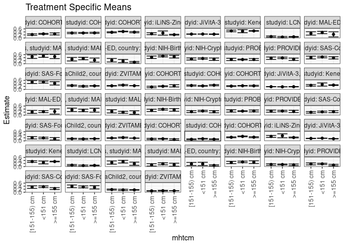

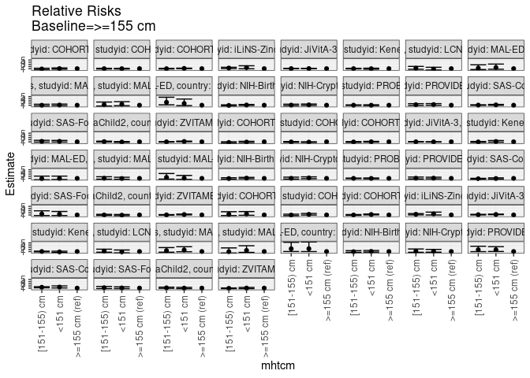

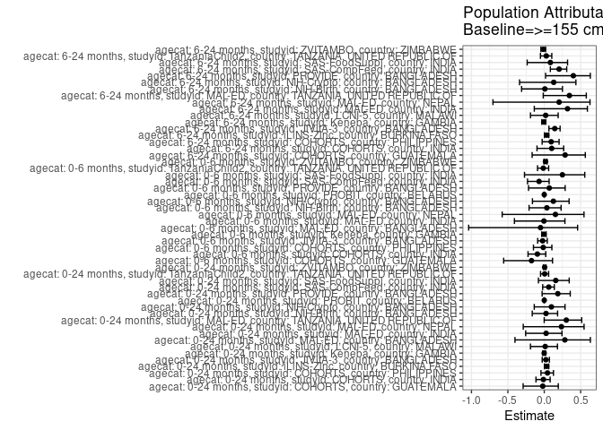

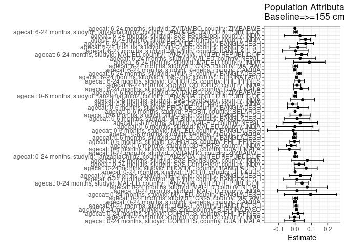

## Results Table

### Parameter: TSM

| agecat | studyid | country | intervention_level | baseline_level | estimate | ci_lower | ci_upper |
| --- | --- | --- | --- | --- | --- | --- | --- |
| 0-24 months | COHORTS | GUATEMALA | >=155 cm | NA | 0.2682062 | 0.2008111 | 0.3356013 |
| 0-24 months | COHORTS | GUATEMALA | <151 cm | NA | 0.2726600 | 0.2424074 | 0.3029127 |
| 0-24 months | COHORTS | GUATEMALA | [151-155) cm | NA | 0.2280039 | 0.1787400 | 0.2772678 |
| 0-24 months | COHORTS | INDIA | >=155 cm | NA | 0.3378741 | 0.2991726 | 0.3765756 |
| 0-24 months | COHORTS | INDIA | <151 cm | NA | 0.3313987 | 0.2991998 | 0.3635977 |
| 0-24 months | COHORTS | INDIA | [151-155) cm | NA | 0.3319765 | 0.2908403 | 0.3731127 |
| 0-24 months | COHORTS | PHILIPPINES | >=155 cm | NA | 0.3857323 | 0.3471229 | 0.4243417 |
| 0-24 months | COHORTS | PHILIPPINES | <151 cm | NA | 0.4284943 | 0.4037548 | 0.4532338 |
| 0-24 months | COHORTS | PHILIPPINES | [151-155) cm | NA | 0.3758798 | 0.3432390 | 0.4085206 |
| 0-24 months | iLiNS-Zinc | BURKINA FASO | >=155 cm | NA | 0.2202920 | 0.1913434 | 0.2492406 |
| 0-24 months | iLiNS-Zinc | BURKINA FASO | <151 cm | NA | 0.3264823 | 0.1902720 | 0.4626926 |
| 0-24 months | iLiNS-Zinc | BURKINA FASO | [151-155) cm | NA | 0.2834244 | 0.2207615 | 0.3460872 |
| 0-24 months | JiVitA-3 | BANGLADESH | >=155 cm | NA | 0.2522991 | 0.2377110 | 0.2668873 |
| 0-24 months | JiVitA-3 | BANGLADESH | <151 cm | NA | 0.2605613 | 0.2526725 | 0.2684500 |
| 0-24 months | JiVitA-3 | BANGLADESH | [151-155) cm | NA | 0.2586373 | 0.2469704 | 0.2703041 |
| 0-24 months | Keneba | GAMBIA | >=155 cm | NA | 0.4669804 | 0.4452028 | 0.4887581 |
| 0-24 months | Keneba | GAMBIA | <151 cm | NA | 0.4512386 | 0.3496031 | 0.5528742 |
| 0-24 months | Keneba | GAMBIA | [151-155) cm | NA | 0.4666455 | 0.4121319 | 0.5211591 |
| 0-24 months | LCNI-5 | MALAWI | >=155 cm | NA | 0.0778210 | 0.0546480 | 0.1009940 |
| 0-24 months | LCNI-5 | MALAWI | <151 cm | NA | 0.0610687 | 0.0200390 | 0.1020984 |
| 0-24 months | LCNI-5 | MALAWI | [151-155) cm | NA | 0.0937500 | 0.0524959 | 0.1350041 |
| 0-24 months | MAL-ED | BANGLADESH | >=155 cm | NA | 0.2400000 | 0.0722560 | 0.4077440 |
| 0-24 months | MAL-ED | BANGLADESH | <151 cm | NA | 0.3619632 | 0.2880425 | 0.4358839 |
| 0-24 months | MAL-ED | BANGLADESH | [151-155) cm | NA | 0.3030303 | 0.1919383 | 0.4141223 |
| 0-24 months | MAL-ED | INDIA | >=155 cm | NA | 0.4711616 | 0.3357316 | 0.6065916 |
| 0-24 months | MAL-ED | INDIA | <151 cm | NA | 0.5129401 | 0.4206967 | 0.6051836 |
| 0-24 months | MAL-ED | INDIA | [151-155) cm | NA | 0.4626535 | 0.3457242 | 0.5795827 |
| 0-24 months | MAL-ED | NEPAL | >=155 cm | NA | 0.2376164 | 0.1032418 | 0.3719910 |
| 0-24 months | MAL-ED | NEPAL | <151 cm | NA | 0.3424789 | 0.2620083 | 0.4229494 |
| 0-24 months | MAL-ED | NEPAL | [151-155) cm | NA | 0.2974810 | 0.1829036 | 0.4120585 |

[output cut: 126 more lines]

### Parameter: E(Y)

| agecat | studyid | country | intervention_level | baseline_level | estimate | ci_lower | ci_upper |
| --- | --- | --- | --- | --- | --- | --- | --- |
| 0-24 months | COHORTS | GUATEMALA | NA | NA | 0.2627451 | 0.2385772 | 0.2869130 |
| 0-24 months | COHORTS | INDIA | NA | NA | 0.3338583 | 0.3126757 | 0.3550409 |
| 0-24 months | COHORTS | PHILIPPINES | NA | NA | 0.4036125 | 0.3861835 | 0.4210415 |
| 0-24 months | iLiNS-Zinc | BURKINA FASO | NA | NA | 0.2278520 | 0.2008644 | 0.2548397 |
| 0-24 months | JiVitA-3 | BANGLADESH | NA | NA | 0.2580393 | 0.2515701 | 0.2645084 |
| 0-24 months | Keneba | GAMBIA | NA | NA | 0.4663106 | 0.4464881 | 0.4861331 |
| 0-24 months | LCNI-5 | MALAWI | NA | NA | 0.0788530 | 0.0605839 | 0.0971222 |
| 0-24 months | MAL-ED | BANGLADESH | NA | NA | 0.3346457 | 0.2765014 | 0.3927899 |
| 0-24 months | MAL-ED | INDIA | NA | NA | 0.4834711 | 0.4203794 | 0.5465628 |
| 0-24 months | MAL-ED | NEPAL | NA | NA | 0.3109244 | 0.2519946 | 0.3698541 |
| 0-24 months | MAL-ED | TANZANIA, UNITED REPUBLIC OF | NA | NA | 0.1406250 | 0.0979572 | 0.1832928 |
| 0-24 months | NIH-Birth | BANGLADESH | NA | NA | 0.4775641 | 0.4383415 | 0.5167867 |
| 0-24 months | NIH-Crypto | BANGLADESH | NA | NA | 0.3298013 | 0.2962438 | 0.3633589 |
| 0-24 months | PROBIT | BELARUS | NA | NA | 0.2807631 | 0.2185905 | 0.3429356 |
| 0-24 months | PROVIDE | BANGLADESH | NA | NA | 0.3602392 | 0.3238339 | 0.3966444 |
| 0-24 months | SAS-CompFeed | INDIA | NA | NA | 0.4107914 | 0.3512139 | 0.4703688 |
| 0-24 months | SAS-FoodSuppl | INDIA | NA | NA | 0.4743276 | 0.4258753 | 0.5227800 |
| 0-24 months | TanzaniaChild2 | TANZANIA, UNITED REPUBLIC OF | NA | NA | 0.2369648 | 0.2198019 | 0.2541277 |
| 0-24 months | ZVITAMBO | ZIMBABWE | NA | NA | 0.2467955 | 0.2382720 | 0.2553190 |
| 0-6 months | COHORTS | GUATEMALA | NA | NA | 0.2019139 | 0.1775635 | 0.2262643 |
| 0-6 months | COHORTS | INDIA | NA | NA | 0.2528180 | 0.2330767 | 0.2725593 |
| 0-6 months | COHORTS | PHILIPPINES | NA | NA | 0.2355453 | 0.2204685 | 0.2506222 |
| 0-6 months | JiVitA-3 | BANGLADESH | NA | NA | 0.1762154 | 0.1705946 | 0.1818362 |
| 0-6 months | Keneba | GAMBIA | NA | NA | 0.2843909 | 0.2653574 | 0.3034244 |
| 0-6 months | MAL-ED | BANGLADESH | NA | NA | 0.2283465 | 0.1766220 | 0.2800709 |
| 0-6 months | MAL-ED | INDIA | NA | NA | 0.3264463 | 0.2672449 | 0.3856476 |
| 0-6 months | MAL-ED | NEPAL | NA | NA | 0.2016807 | 0.1505956 | 0.2527658 |
| 0-6 months | NIH-Birth | BANGLADESH | NA | NA | 0.3569132 | 0.3192325 | 0.3945938 |
| 0-6 months | NIH-Crypto | BANGLADESH | NA | NA | 0.2569536 | 0.2257649 | 0.2881424 |
| 0-6 months | PROBIT | BELARUS | NA | NA | 0.2750109 | 0.2125981 | 0.3374238 |
| 0-6 months | PROVIDE | BANGLADESH | NA | NA | 0.2630792 | 0.2296894 | 0.2964690 |
| 0-6 months | SAS-CompFeed | INDIA | NA | NA | 0.2154736 | 0.1691818 | 0.2617655 |
| 0-6 months | SAS-FoodSuppl | INDIA | NA | NA | 0.1833741 | 0.1458251 | 0.2209231 |
| 0-6 months | TanzaniaChild2 | TANZANIA, UNITED REPUBLIC OF | NA | NA | 0.1394659 | 0.1254831 | 0.1534487 |
| 0-6 months | ZVITAMBO | ZIMBABWE | NA | NA | 0.1822917 | 0.1746442 | 0.1899391 |
| 6-24 months | COHORTS | GUATEMALA | NA | NA | 0.1288927 | 0.1095683 | 0.1482172 |
| 6-24 months | COHORTS | INDIA | NA | NA | 0.1199132 | 0.1050778 | 0.1347486 |
| 6-24 months | COHORTS | PHILIPPINES | NA | NA | 0.2666429 | 0.2502871 | 0.2829988 |
| 6-24 months | iLiNS-Zinc | BURKINA FASO | NA | NA | 0.2278520 | 0.2008644 | 0.2548397 |
| 6-24 months | JiVitA-3 | BANGLADESH | NA | NA | 0.1637386 | 0.1576238 | 0.1698535 |
| 6-24 months | Keneba | GAMBIA | NA | NA | 0.3284609 | 0.3093705 | 0.3475512 |
| 6-24 months | LCNI-5 | MALAWI | NA | NA | 0.0765492 | 0.0583736 | 0.0947248 |
| 6-24 months | MAL-ED | INDIA | NA | NA | 0.2735043 | 0.2162683 | 0.3307402 |
| 6-24 months | MAL-ED | NEPAL | NA | NA | 0.1531915 | 0.1070438 | 0.1993392 |
| 6-24 months | MAL-ED | TANZANIA, UNITED REPUBLIC OF | NA | NA | 0.1142857 | 0.0743652 | 0.1542062 |
| 6-24 months | NIH-Birth | BANGLADESH | NA | NA | 0.2933579 | 0.2549918 | 0.3317241 |
| 6-24 months | NIH-Crypto | BANGLADESH | NA | NA | 0.1315068 | 0.1069744 | 0.1560393 |
| 6-24 months | PROVIDE | BANGLADESH | NA | NA | 0.1612378 | 0.1321259 | 0.1903497 |
| 6-24 months | SAS-CompFeed | INDIA | NA | NA | 0.3077525 | 0.2591695 | 0.3563356 |
| 6-24 months | SAS-FoodSuppl | INDIA | NA | NA | 0.3566085 | 0.3096676 | 0.4035494 |
| 6-24 months | TanzaniaChild2 | TANZANIA, UNITED REPUBLIC OF | NA | NA | 0.1617128 | 0.1455117 | 0.1779140 |
| 6-24 months | ZVITAMBO | ZIMBABWE | NA | NA | 0.0985622 | 0.0922708 | 0.1048535 |

### Parameter: RR

| agecat | studyid | country | intervention_level | baseline_level | estimate | ci_lower | ci_upper |
| --- | --- | --- | --- | --- | --- | --- | --- |
| 0-24 months | COHORTS | GUATEMALA | >=155 cm | >=155 cm | 1.0000000 | 1.0000000 | 1.000000 |
| 0-24 months | COHORTS | GUATEMALA | <151 cm | >=155 cm | 1.0166061 | 0.7729757 | 1.337025 |
| 0-24 months | COHORTS | GUATEMALA | [151-155) cm | >=155 cm | 0.8501069 | 0.6106740 | 1.183417 |
| 0-24 months | COHORTS | INDIA | >=155 cm | >=155 cm | 1.0000000 | 1.0000000 | 1.000000 |
| 0-24 months | COHORTS | INDIA | <151 cm | >=155 cm | 0.9808350 | 0.8441612 | 1.139637 |
| 0-24 months | COHORTS | INDIA | [151-155) cm | >=155 cm | 0.9825451 | 0.8300537 | 1.163051 |
| 0-24 months | COHORTS | PHILIPPINES | >=155 cm | >=155 cm | 1.0000000 | 1.0000000 | 1.000000 |
| 0-24 months | COHORTS | PHILIPPINES | <151 cm | >=155 cm | 1.1108592 | 0.9896734 | 1.246884 |
| 0-24 months | COHORTS | PHILIPPINES | [151-155) cm | >=155 cm | 0.9744577 | 0.8535035 | 1.112553 |
| 0-24 months | iLiNS-Zinc | BURKINA FASO | >=155 cm | >=155 cm | 1.0000000 | 1.0000000 | 1.000000 |
| 0-24 months | iLiNS-Zinc | BURKINA FASO | <151 cm | >=155 cm | 1.4820433 | 0.9381862 | 2.341169 |
| 0-24 months | iLiNS-Zinc | BURKINA FASO | [151-155) cm | >=155 cm | 1.2865847 | 1.0153062 | 1.630346 |
| 0-24 months | JiVitA-3 | BANGLADESH | >=155 cm | >=155 cm | 1.0000000 | 1.0000000 | 1.000000 |
| 0-24 months | JiVitA-3 | BANGLADESH | <151 cm | >=155 cm | 1.0327474 | 0.9727282 | 1.096470 |
| 0-24 months | JiVitA-3 | BANGLADESH | [151-155) cm | >=155 cm | 1.0251215 | 0.9538392 | 1.101731 |
| 0-24 months | Keneba | GAMBIA | >=155 cm | >=155 cm | 1.0000000 | 1.0000000 | 1.000000 |
| 0-24 months | Keneba | GAMBIA | <151 cm | >=155 cm | 0.9662903 | 0.7677611 | 1.216155 |
| 0-24 months | Keneba | GAMBIA | [151-155) cm | >=155 cm | 0.9992828 | 0.8811978 | 1.133192 |
| 0-24 months | LCNI-5 | MALAWI | >=155 cm | >=155 cm | 1.0000000 | 1.0000000 | 1.000000 |
| 0-24 months | LCNI-5 | MALAWI | <151 cm | >=155 cm | 0.7847328 | 0.3763243 | 1.636370 |
| 0-24 months | LCNI-5 | MALAWI | [151-155) cm | >=155 cm | 1.2046875 | 0.7081457 | 2.049397 |
| 0-24 months | MAL-ED | BANGLADESH | >=155 cm | >=155 cm | 1.0000000 | 1.0000000 | 1.000000 |
| 0-24 months | MAL-ED | BANGLADESH | <151 cm | >=155 cm | 1.5081800 | 0.7281453 | 3.123836 |
| 0-24 months | MAL-ED | BANGLADESH | [151-155) cm | >=155 cm | 1.2626263 | 0.5734697 | 2.779964 |
| 0-24 months | MAL-ED | INDIA | >=155 cm | >=155 cm | 1.0000000 | 1.0000000 | 1.000000 |
| 0-24 months | MAL-ED | INDIA | <151 cm | >=155 cm | 1.0886714 | 0.7758654 | 1.527591 |
| 0-24 months | MAL-ED | INDIA | [151-155) cm | >=155 cm | 0.9819422 | 0.6686399 | 1.442047 |
| 0-24 months | MAL-ED | NEPAL | >=155 cm | >=155 cm | 1.0000000 | 1.0000000 | 1.000000 |
| 0-24 months | MAL-ED | NEPAL | <151 cm | >=155 cm | 1.4413100 | 0.7815787 | 2.657921 |
| 0-24 months | MAL-ED | NEPAL | [151-155) cm | >=155 cm | 1.2519381 | 0.6312429 | 2.482957 |

[output cut: 126 more lines]

### Parameter: PAR

| agecat | studyid | country | intervention_level | baseline_level | estimate | ci_lower | ci_upper |
| --- | --- | --- | --- | --- | --- | --- | --- |
| 0-24 months | COHORTS | GUATEMALA | >=155 cm | NA | -0.0054611 | -0.0682976 | 0.0573754 |
| 0-24 months | COHORTS | INDIA | >=155 cm | NA | -0.0040158 | -0.0364222 | 0.0283906 |
| 0-24 months | COHORTS | PHILIPPINES | >=155 cm | NA | 0.0178802 | -0.0166907 | 0.0524511 |
| 0-24 months | iLiNS-Zinc | BURKINA FASO | >=155 cm | NA | 0.0075600 | 0.0009809 | 0.0141391 |
| 0-24 months | JiVitA-3 | BANGLADESH | >=155 cm | NA | 0.0057402 | -0.0070112 | 0.0184915 |
| 0-24 months | Keneba | GAMBIA | >=155 cm | NA | -0.0006698 | -0.0097172 | 0.0083775 |
| 0-24 months | LCNI-5 | MALAWI | >=155 cm | NA | 0.0010320 | -0.0135015 | 0.0155656 |
| 0-24 months | MAL-ED | BANGLADESH | >=155 cm | NA | 0.0946457 | -0.0665369 | 0.2558283 |
| 0-24 months | MAL-ED | INDIA | >=155 cm | NA | 0.0123095 | -0.1070669 | 0.1316858 |
| 0-24 months | MAL-ED | NEPAL | >=155 cm | NA | 0.0733080 | -0.0508678 | 0.1974838 |
| 0-24 months | MAL-ED | TANZANIA, UNITED REPUBLIC OF | >=155 cm | NA | 0.0425858 | 0.0053674 | 0.0798042 |
| 0-24 months | NIH-Birth | BANGLADESH | >=155 cm | NA | 0.0116301 | -0.0711242 | 0.0943844 |
| 0-24 months | NIH-Crypto | BANGLADESH | >=155 cm | NA | 0.0323897 | -0.0366926 | 0.1014721 |
| 0-24 months | PROBIT | BELARUS | >=155 cm | NA | 0.0000155 | -0.0013561 | 0.0013870 |
| 0-24 months | PROVIDE | BANGLADESH | >=155 cm | NA | 0.0670883 | -0.0018991 | 0.1360757 |
| 0-24 months | SAS-CompFeed | INDIA | >=155 cm | NA | 0.0252576 | -0.0061065 | 0.0566216 |
| 0-24 months | SAS-FoodSuppl | INDIA | >=155 cm | NA | 0.0746566 | -0.0244458 | 0.1737590 |
| 0-24 months | TanzaniaChild2 | TANZANIA, UNITED REPUBLIC OF | >=155 cm | NA | 0.0014587 | -0.0116692 | 0.0145866 |
| 0-24 months | ZVITAMBO | ZIMBABWE | >=155 cm | NA | 0.0013589 | -0.0029912 | 0.0057090 |
| 0-6 months | COHORTS | GUATEMALA | >=155 cm | NA | -0.0353481 | -0.1023056 | 0.0316093 |
| 0-6 months | COHORTS | INDIA | >=155 cm | NA | -0.0238486 | -0.0546141 | 0.0069168 |
| 0-6 months | COHORTS | PHILIPPINES | >=155 cm | NA | -0.0033419 | -0.0330502 | 0.0263664 |
| 0-6 months | JiVitA-3 | BANGLADESH | >=155 cm | NA | -0.0039999 | -0.0155890 | 0.0075892 |
| 0-6 months | Keneba | GAMBIA | >=155 cm | NA | -0.0011402 | -0.0096891 | 0.0074087 |
| 0-6 months | MAL-ED | BANGLADESH | >=155 cm | NA | -0.0116535 | -0.1706331 | 0.1473260 |
| 0-6 months | MAL-ED | INDIA | >=155 cm | NA | -0.0016046 | -0.1126945 | 0.1094853 |
| 0-6 months | MAL-ED | NEPAL | >=155 cm | NA | 0.0309490 | -0.0755469 | 0.1374448 |
| 0-6 months | NIH-Birth | BANGLADESH | >=155 cm | NA | 0.0128431 | -0.0650244 | 0.0907105 |
| 0-6 months | NIH-Crypto | BANGLADESH | >=155 cm | NA | 0.0321174 | -0.0317254 | 0.0959602 |
| 0-6 months | PROBIT | BELARUS | >=155 cm | NA | -0.0000726 | -0.0013271 | 0.0011819 |
| 0-6 months | PROVIDE | BANGLADESH | >=155 cm | NA | 0.0181172 | -0.0472785 | 0.0835128 |
| 0-6 months | SAS-CompFeed | INDIA | >=155 cm | NA | -0.0153744 | -0.0482530 | 0.0175042 |
| 0-6 months | SAS-FoodSuppl | INDIA | >=155 cm | NA | 0.0456652 | -0.0271290 | 0.1184594 |
| 0-6 months | TanzaniaChild2 | TANZANIA, UNITED REPUBLIC OF | >=155 cm | NA | -0.0018473 | -0.0124935 | 0.0087990 |
| 0-6 months | ZVITAMBO | ZIMBABWE | >=155 cm | NA | 0.0031235 | -0.0008353 | 0.0070822 |
| 6-24 months | COHORTS | GUATEMALA | >=155 cm | NA | 0.0369623 | -0.0085070 | 0.0824317 |
| 6-24 months | COHORTS | INDIA | >=155 cm | NA | 0.0122297 | -0.0096795 | 0.0341390 |
| 6-24 months | COHORTS | PHILIPPINES | >=155 cm | NA | 0.0252550 | -0.0057807 | 0.0562908 |
| 6-24 months | iLiNS-Zinc | BURKINA FASO | >=155 cm | NA | 0.0075453 | 0.0009489 | 0.0141417 |
| 6-24 months | JiVitA-3 | BANGLADESH | >=155 cm | NA | 0.0236087 | 0.0110673 | 0.0361501 |
| 6-24 months | Keneba | GAMBIA | >=155 cm | NA | -0.0020758 | -0.0108102 | 0.0066585 |
| 6-24 months | LCNI-5 | MALAWI | >=155 cm | NA | 0.0014504 | -0.0130102 | 0.0159110 |
| 6-24 months | MAL-ED | INDIA | >=155 cm | NA | 0.0873179 | -0.0090898 | 0.1837255 |
| 6-24 months | MAL-ED | NEPAL | >=155 cm | NA | 0.0312403 | -0.0619769 | 0.1244574 |
| 6-24 months | MAL-ED | TANZANIA, UNITED REPUBLIC OF | >=155 cm | NA | 0.0394558 | 0.0043797 | 0.0745319 |
| 6-24 months | NIH-Birth | BANGLADESH | >=155 cm | NA | 0.0024020 | -0.0788544 | 0.0836585 |
| 6-24 months | NIH-Crypto | BANGLADESH | >=155 cm | NA | 0.0170710 | -0.0323817 | 0.0665237 |
| 6-24 months | PROVIDE | BANGLADESH | >=155 cm | NA | 0.0643790 | 0.0157470 | 0.1130111 |
| 6-24 months | SAS-CompFeed | INDIA | >=155 cm | NA | 0.0627874 | 0.0308714 | 0.0947035 |
| 6-24 months | SAS-FoodSuppl | INDIA | >=155 cm | NA | 0.0298497 | -0.0676207 | 0.1273200 |
| 6-24 months | TanzaniaChild2 | TANZANIA, UNITED REPUBLIC OF | >=155 cm | NA | 0.0046132 | -0.0079917 | 0.0172181 |
| 6-24 months | ZVITAMBO | ZIMBABWE | >=155 cm | NA | -0.0013057 | -0.0044768 | 0.0018654 |

### Parameter: PAF

| agecat | studyid | country | intervention_level | baseline_level | estimate | ci_lower | ci_upper |
| --- | --- | --- | --- | --- | --- | --- | --- |
| 0-24 months | COHORTS | GUATEMALA | >=155 cm | NA | -0.0207847 | -0.2902779 | 0.1924210 |
| 0-24 months | COHORTS | INDIA | >=155 cm | NA | -0.0120285 | -0.1139060 | 0.0805314 |
| 0-24 months | COHORTS | PHILIPPINES | >=155 cm | NA | 0.0443004 | -0.0453179 | 0.1262355 |
| 0-24 months | iLiNS-Zinc | BURKINA FASO | >=155 cm | NA | 0.0331795 | 0.0028538 | 0.0625829 |
| 0-24 months | JiVitA-3 | BANGLADESH | >=155 cm | NA | 0.0222453 | -0.0284740 | 0.0704634 |
| 0-24 months | Keneba | GAMBIA | >=155 cm | NA | -0.0014364 | -0.0210277 | 0.0177790 |
| 0-24 months | LCNI-5 | MALAWI | >=155 cm | NA | 0.0130881 | -0.1895327 | 0.1811952 |
| 0-24 months | MAL-ED | BANGLADESH | >=155 cm | NA | 0.2828235 | -0.4024019 | 0.6332420 |
| 0-24 months | MAL-ED | INDIA | >=155 cm | NA | 0.0254606 | -0.2556125 | 0.2436145 |
| 0-24 months | MAL-ED | NEPAL | >=155 cm | NA | 0.2357743 | -0.2886938 | 0.5467963 |
| 0-24 months | MAL-ED | TANZANIA, UNITED REPUBLIC OF | >=155 cm | NA | 0.3028322 | -0.0008100 | 0.5143505 |
| 0-24 months | NIH-Birth | BANGLADESH | >=155 cm | NA | 0.0243530 | -0.1652843 | 0.1831289 |
| 0-24 months | NIH-Crypto | BANGLADESH | >=155 cm | NA | 0.0982098 | -0.1375619 | 0.2851154 |
| 0-24 months | PROBIT | BELARUS | >=155 cm | NA | 0.0000550 | -0.0048437 | 0.0049299 |
| 0-24 months | PROVIDE | BANGLADESH | >=155 cm | NA | 0.1862327 | -0.0294870 | 0.3567503 |
| 0-24 months | SAS-CompFeed | INDIA | >=155 cm | NA | 0.0614851 | -0.0218675 | 0.1380388 |
| 0-24 months | SAS-FoodSuppl | INDIA | >=155 cm | NA | 0.1573946 | -0.0800716 | 0.3426512 |
| 0-24 months | TanzaniaChild2 | TANZANIA, UNITED REPUBLIC OF | >=155 cm | NA | 0.0061557 | -0.0508175 | 0.0600400 |
| 0-24 months | ZVITAMBO | ZIMBABWE | >=155 cm | NA | 0.0055061 | -0.0122769 | 0.0229768 |
| 0-6 months | COHORTS | GUATEMALA | >=155 cm | NA | -0.1750654 | -0.5577203 | 0.1135901 |
| 0-6 months | COHORTS | INDIA | >=155 cm | NA | -0.0943313 | -0.2230007 | 0.0208011 |
| 0-6 months | COHORTS | PHILIPPINES | >=155 cm | NA | -0.0141880 | -0.1484889 | 0.1044082 |
| 0-6 months | JiVitA-3 | BANGLADESH | >=155 cm | NA | -0.0226990 | -0.0905989 | 0.0409735 |
| 0-6 months | Keneba | GAMBIA | >=155 cm | NA | -0.0040092 | -0.0345243 | 0.0256059 |
| 0-6 months | MAL-ED | BANGLADESH | >=155 cm | NA | -0.0510345 | -1.0383796 | 0.4580629 |
| 0-6 months | MAL-ED | INDIA | >=155 cm | NA | -0.0049153 | -0.4099333 | 0.2837570 |
| 0-6 months | MAL-ED | NEPAL | >=155 cm | NA | 0.1534553 | -0.5780681 | 0.5458764 |
| 0-6 months | NIH-Birth | BANGLADESH | >=155 cm | NA | 0.0359837 | -0.2088227 | 0.2312128 |
| 0-6 months | NIH-Crypto | BANGLADESH | >=155 cm | NA | 0.1249930 | -0.1622115 | 0.3412238 |
| 0-6 months | PROBIT | BELARUS | >=155 cm | NA | -0.0002640 | -0.0048249 | 0.0042761 |
| 0-6 months | PROVIDE | BANGLADESH | >=155 cm | NA | 0.0688659 | -0.2159434 | 0.2869646 |
| 0-6 months | SAS-CompFeed | INDIA | >=155 cm | NA | -0.0713515 | -0.2298492 | 0.0667197 |
| 0-6 months | SAS-FoodSuppl | INDIA | >=155 cm | NA | 0.2490275 | -0.2716510 | 0.5565138 |
| 0-6 months | TanzaniaChild2 | TANZANIA, UNITED REPUBLIC OF | >=155 cm | NA | -0.0132453 | -0.0925209 | 0.0602780 |
| 0-6 months | ZVITAMBO | ZIMBABWE | >=155 cm | NA | 0.0171345 | -0.0048176 | 0.0386070 |
| 6-24 months | COHORTS | GUATEMALA | >=155 cm | NA | 0.2867680 | -0.1667434 | 0.5640002 |
| 6-24 months | COHORTS | INDIA | >=155 cm | NA | 0.1019883 | -0.0997867 | 0.2667442 |
| 6-24 months | COHORTS | PHILIPPINES | >=155 cm | NA | 0.0947148 | -0.0293381 | 0.2038172 |
| 6-24 months | iLiNS-Zinc | BURKINA FASO | >=155 cm | NA | 0.0331149 | 0.0027042 | 0.0625982 |
| 6-24 months | JiVitA-3 | BANGLADESH | >=155 cm | NA | 0.1441853 | 0.0639018 | 0.2175834 |
| 6-24 months | Keneba | GAMBIA | >=155 cm | NA | -0.0063199 | -0.0332685 | 0.0199259 |
| 6-24 months | LCNI-5 | MALAWI | >=155 cm | NA | 0.0189472 | -0.1893171 | 0.1907419 |
| 6-24 months | MAL-ED | INDIA | >=155 cm | NA | 0.3192559 | -0.1369911 | 0.5924221 |
| 6-24 months | MAL-ED | NEPAL | >=155 cm | NA | 0.2039295 | -0.7049484 | 0.6283007 |
| 6-24 months | MAL-ED | TANZANIA, UNITED REPUBLIC OF | >=155 cm | NA | 0.3452381 | -0.0142598 | 0.5773143 |
| 6-24 months | NIH-Birth | BANGLADESH | >=155 cm | NA | 0.0081880 | -0.3113426 | 0.2498596 |
| 6-24 months | NIH-Crypto | BANGLADESH | >=155 cm | NA | 0.1298107 | -0.3395618 | 0.4347186 |
| 6-24 months | PROVIDE | BANGLADESH | >=155 cm | NA | 0.3992800 | 0.0182352 | 0.6324329 |
| 6-24 months | SAS-CompFeed | INDIA | >=155 cm | NA | 0.2040192 | 0.0837256 | 0.3085201 |
| 6-24 months | SAS-FoodSuppl | INDIA | >=155 cm | NA | 0.0837044 | -0.2347662 | 0.3200351 |
| 6-24 months | TanzaniaChild2 | TANZANIA, UNITED REPUBLIC OF | >=155 cm | NA | 0.0285270 | -0.0526054 | 0.1034059 |
| 6-24 months | ZVITAMBO | ZIMBABWE | >=155 cm | NA | -0.0132475 | -0.0459334 | 0.0184170 |